# DATA SCIENCE COURSEWORK NUMBER 2

## 2.3.2 Community detection

In this task, we use the NetworkX library to implement a Clauset-Newman-Moore greedy modularity maximisation algorithm in order to compute the optimal number of communities.

```python
### IMPORT NECESSARY LIBRARIES ###
import numpy as np
import pandas as pd
import matplotlib.pyplot as plt
import scipy as sc
import networkx as nx
```

```python
### Adjacency matrix A ###
A = pd.read_csv("/content/karate_club_graph.csv")
A.drop(A.columns[[0]], axis=1, inplace=True) #delete first column
A.head()
```

|  | 0 | 1 | 2 | 3 | 4 | 5 | 6 | 7 | 8 | 9 | 10 | 11 | 12 | 13 | 14 | 15 | 16 | 17 | 18 | 19 | 20 | 21 | 22 | 23 | 24 | 25 | 26 | 27 | 28 | … |
| --- | --- | --- | --- | --- | --- | --- | --- | --- | --- | --- | --- | --- | --- | --- | --- | --- | --- | --- | --- | --- | --- | --- | --- | --- | --- | --- | --- | --- | --- | --- |
| 0 | 0.0 | 1.0 | 1.0 | 1.0 | 1.0 | 1.0 | 1.0 | 1.0 | 1.0 | 0.0 | 1.0 | 1.0 | 1.0 | 1.0 | 0.0 | 0.0 | 0.0 | 1.0 | 0.0 | 1.0 | 0.0 | 1.0 | 0.0 | 0.0 | 0.0 | 0.0 | 0.0 | 0.0 | 0.0 | … |
| 1 | 1.0 | 0.0 | 1.0 | 1.0 | 0.0 | 0.0 | 0.0 | 1.0 | 0.0 | 0.0 | 0.0 | 0.0 | 0.0 | 1.0 | 0.0 | 0.0 | 0.0 | 1.0 | 0.0 | 1.0 | 0.0 | 1.0 | 0.0 | 0.0 | 0.0 | 0.0 | 0.0 | 0.0 | 0.0 | … |
| 2 | 1.0 | 1.0 | 0.0 | 1.0 | 0.0 | 0.0 | 0.0 | 1.0 | 1.0 | 1.0 | 0.0 | 0.0 | 0.0 | 1.0 | 0.0 | 0.0 | 0.0 | 0.0 | 0.0 | 0.0 | 0.0 | 0.0 | 0.0 | 0.0 | 0.0 | 0.0 | 0.0 | 1.0 | 1.0 | … |
| 3 | 1.0 | 1.0 | 1.0 | 0.0 | 0.0 | 0.0 | 0.0 | 1.0 | 0.0 | 0.0 | 0.0 | 0.0 | 1.0 | 1.0 | 0.0 | 0.0 | 0.0 | 0.0 | 0.0 | 0.0 | 0.0 | 0.0 | 0.0 | 0.0 | 0.0 | 0.0 | 0.0 | 0.0 | 0.0 | … |
| 4 | 1.0 | 0.0 | 0.0 | 0.0 | 0.0 | 0.0 | 1.0 | 0.0 | 0.0 | 0.0 | 1.0 | 0.0 | 0.0 | 0.0 | 0.0 | 0.0 | 0.0 | 0.0 | 0.0 | 0.0 | 0.0 | 0.0 | 0.0 | 0.0 | 0.0 | 0.0 | 0.0 | 0.0 | 0.0 | … |

```python
### COMPUTE COMMUNITIES ###
from networkx.algorithms.community import greedy_modularity_communities
G = nx.from_numpy_matrix(np.array(A))
pos = nx.spring_layout(G)

CNM_list = list(greedy_modularity_communities(G)) # labels

communities = [sorted(CNM_list[i]) for i in range(len(CNM_list))]
```

```python
print('Optimal number of communities k*:', len(communities))
```

```
Optimal number of communities k*: 3
```

Now, let's print the corresponding partitions of the karate club graph to the optimal number of communities k=3.

```python
### PRINT PARTITIONS OF OUR NODES WITHIN THE SAME COMMUNITY ###
partition = pd.DataFrame({'communities': np.arange(0,3,1),'partitions': np.array(communities)})
partition.set_index('communities', inplace=True)
partition.head(3)
```

| communities | partitions |
| --- | --- |
| 0 | [8, 14, 15, 18, 20, 22, 23, 24, 25, 26, 27, 28... |
| 1 | [1, 2, 3, 7, 9, 12, 13, 17, 21] |
| 2 | [0, 4, 5, 6, 10, 11, 16, 19] |

Now plot the communities distribution to see their size relative to each other.

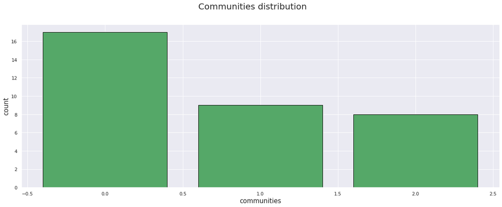

```python
### COMMUNITIES DISTRIBUTION PLOT ###

# initialization
partition_dist = np.zeros(3)

# for loop: computing size of each community
for i in range(len(communities)):
    partition_dist[i] = (len(communities[i]))

# plot
sns.set()

plt.figure(figsize=(20,7))
plt.bar(np.arange(0,3), partition_dist, color='g', edgecolor='black')
plt.xlabel('communities', fontsize=15)
plt.ylabel('count', fontsize=15)
plt.suptitle('Communities distribution', fontsize=20)

plt.show()
```

```python
### FIND CLUSTERS FOR OUR BEST NUMBER OF COMMUNITIES ###

# initialization
n = np.arange(len(communities)) # pick range of number of communitities
color_map1 = [0]*34 # choose how to color the graph

# for loop: labeling each node by its community number
for i in range(len(n)): # loop over number of communities
    for j in range(len(communities[i])): # loop over size of each community
        color_map1[communities[i][j]] = i
```

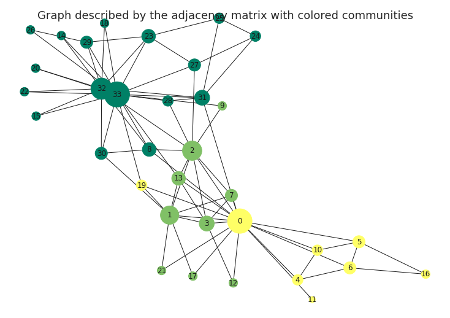

```python
### GRAPH OF ADJACENCY MATRIX WRT TO THEIR COMMUNITIES ###

deg = np.array(degree)*100 # pre-make size of node for better visualization

sns.set_style("white")

plt.figure(figsize=(10,7))
nx.draw(G, pos, node_size=deg, cmap='summer', node_color=color_map1, with_labels = True)
plt.suptitle('Graph described by the adjacency matrix with colored communities', fontsize=18)

plt.show()
```

Now let's plot the distribution of the top 8 most central nodes according to degree centrality and PageRank:

```python
### COMPUTE THE 8 MOST CENTRAL NODES ACCORDING TO DEGREE CENTRALITY AND PAGERANK ###

# initialization: pick top 8 nodes from degree centrality and pagerank
cent_deg, cent_pr = [], []
top_nodes_deg = sorted_deg[0:8]
top_nodes_pr = sorted_pr[0:8]

# for loop to extract most central nodes according to our 2 centrality measures
for node in range(8):
    for i in range(len(communities)):
        for j in range(len(communities[i])):
            # extracting 8 most central nodes according to degree centrality
            if top_nodes_deg[node]==communities[i][j]:
                cent_deg.append(i)
            # extracting 8 most central nodes according to page rank
            if top_nodes_pr[node]==communities[i][j]:
                cent_pr.append(i)
```

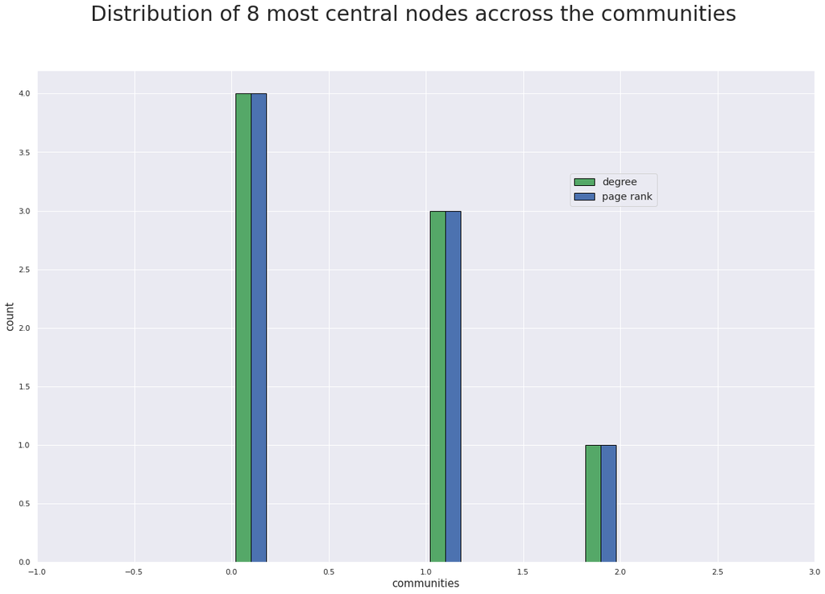

```python
### DISTRIBUTION OF 8 MOST CENTRAL NODES ###

sns.set()

x_dist8 = [cent_deg, cent_pr]

plt.figure(figsize=(20,13))
plt.hist(x_dist8, label=['degree','page rank'], color=['g', 'b'], edgecolor='black')
plt.xlim(-1,len(communities))
plt.xlabel('communities', fontsize=15)
plt.ylabel('count', fontsize=15)
plt.suptitle('Distribution of 8 most central nodes accross the communities', fontsize=30)

plt.legend(loc="upper right", bbox_to_anchor=(0.81,0.81), borderaxespad=1, frameon=True, fontsize='large')

plt.show()
```

**Comment**

This confirms our second correlation matrix. Page Rank and Degree centrality have the same distribution over the 3 communities for the top 8 most central nodes. Indeed this isn't surprising as we saw our correlated their rankings were in 2.3.1.

## 2.3.3 Comparing clusterings

Now we use the Adjusted Rand Index (ARI) to compare clusterings. We can define the ARI as follows: $ARI = \frac{\sum_{i,j} {n_{i,j} \choose 2} - \left[ \sum_i {a_{i} \choose 2} \sum_j {b_{j} \choose 2} \right] / {n \choose 2}}{ \frac{1}{2}\left[ \sum_i {a_{i} \choose 2} \sum_j {b_{j} \choose 2} \right] - \left[ \sum_i {a_{i} \choose 2} \sum_j {b_{j} \choose 2} \right] / {n \choose 2}}$

```python
### IMPORT NECESSARY PACKAGES ###
import pandas as pd
import numpy as np
```

```python
### LOAD GROUND TRUTH MATRIX ###
GT = pd.read_csv("/content/ground_truth_karate_club.csv")
GT.drop(GT.columns[[0]], axis=1, inplace=True) # delete first column
GT.head()
```

|  | 0 |
| --- | --- |
| 0 | Mr. Hi |
| 1 | Mr. Hi |
| 2 | Mr. Hi |
| 3 | Mr. Hi |
| 4 | Mr. Hi |

```python
### CONVERT GT TO NUMPY ###
GT = GT.to_numpy()
```

```python
### CREATE CONSISTENCY TABLE FUNCTION ###

def cons_t(c1, c2):

    N = c1.size # pick length of cluster 1 vector

    # pick vector from cluster 2 with the number of unique entries
    n1 = np.unique(c2)
    N1 = n1.size

    # pick vector from cluster 2 with the number of unique entries
    n2 = np.unique(c1)
    N2 = n2.size

    # ininitialize consistency table to fill
    cons_t = np.zeros((N2+1, N1+1))

    for i in range(N): # loop over cluster size
        cons_t[c1[i], c2[i]] += 1 # update

    # define sum of rows and columns
    s_1 = np.sum(cons_t, axis=1) # column sum
    s_2 = np.sum(cons_t, axis=0) # row sum

    for j in range(N2): # loop over number of unique entries
        cons_t[j, N1] = s_1[j] # update

    for k in range(N1): # loop over number of unique entries
        cons_t[N2, k] = s_2[k] # update

    return cons_t
```

```python
### CREATE ADJUSTED RAND INDEX FUNCTION ###

def ARI(c1, c2):

    # sums from top of fraction
    s_top_1 = 0
    s_top_2 = 0
    # sums from 2nd term of top of fraction
    s_top_21= 0
    s_top_22= 0

    # sums from bottom of fraction
    s_bottom_1 = 0
    s_bottom_2 = 0

    n = c1.size

    # choose unique values from c2
    n1 = np.unique(c2)
    N1 = n1.size

    # choose unique values from c1
    n2 = np.unique(c1)
    N2 = n2.size

    # create initial CT
    CT = cons_t(c1,c2)

    # double loop for first term of top of fraction
    for k in range(N2):
        for l in range(N1):
            s_top_1 += sc.special.binom(CT[k,l],2)

    # compute first sum of second term of top of fraction
    for k in range(N2):
        s_top_21 += sc.special.binom(CT[k,N1],2)

    # compute second sum of second term of top of fraction
    for l in range(N1):
        s_top_22 += sc.special.binom(CT[N2,l],2)

    # divide 2nd term of top of fraction by the combinatorics
    s_top_2 = s_top_21 * s_top_22 / sc.special.binom(n,2)

    # compute first sum from bottom of frac
    for k in range(N2):
        s_bottom_1 += sc.special.binom(CT[k,N1],2)

    for l in range(N1):
        s_bottom_1 += sc.special.binom(CT[N2,l],2)

    s_bottom_1 /= 2 #result for first sum from bottom of frac

    # compute seond sum from bottom of frac
    s_bottom_2 = s_top_2

    return (s_top_1 - s_top_2)/(s_bottom_1-s_bottom_2)
```

```python
# initialization
n = np.arange(len(communities)) # pick range of number of communitities
color_map1 = [0]*34 # choose how to color the graph
labels32 = []

# for loop: labeling each node by its community number
for m in range(100):
  for i in range(len(n)): # loop over number of communities
    for j in range(len(communities[i])): # loop over size of each community
      color_map1[communities[i][j]] = i
      labels32.append(color_map1)

labels32 = np.array(labels32)
```

```python
### LOOK AT ARI FOR DIFFERENT SOLUTIONS OVER 100 ITERATIONS ###
labels31 = []
labels33 = []
ARI31 = []
ARI32 = []
ARI33 = []
ground_truth = [0 if label=="Mr. Hi" else 1 for label in GT]

for i in range(100):
  centroids31, labels301 = k_means(2, F, 15)
  ground_truth = ground_truth
  labels31.append(np.array(labels301))
  labels33.append(np.array(ground_truth))
  ARI31.append(ARI(np.array(labels31[i-1]), np.array(labels32[i-1])))
  ARI32.append(ARI(np.array(labels31[i-1]), np.array(labels33[i-1])))
  ARI33.append(ARI(np.array(labels32[i-1]), np.array(labels33[i-1])))

ari31 = np.mean(ARI31)
ari32 = np.mean(ARI32)
ari33 = np.mean(ARI33)

print("The ARI between k-means and CNM is:", ari31)
print("The ARI between k-means and GT is:", ari32)
print("The ARI between CNM and GT is:", ari33)
```

```
The ARI between k-means and CNM is: -0.027790378065932687
The ARI between k-means and GT is: 0.01154456267004692
The ARI between CNM and GT is: 0.5684394071490848
```

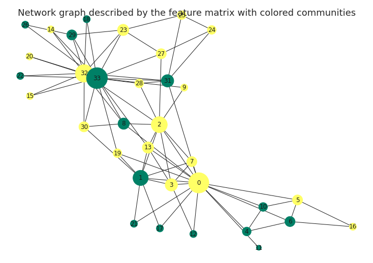

```python
### PLOT NETWORK WITH 2 COMMUNITIES (best k from k means) ###

sns.set_style("white")

plt.figure(figsize=(10,7))
nx.draw(G, pos, with_labels=True, cmap='summer', node_size=deg, node_color=two_one)
plt.suptitle('Network graph described by the feature matrix with colored communities', fontsize=18)

plt.show()
```

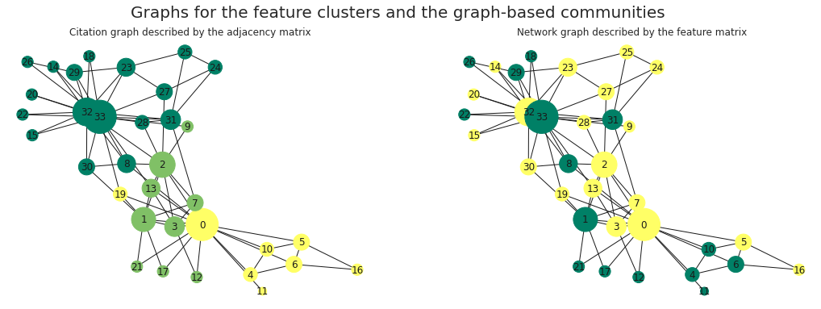

```python
### COMPARISON OF GRAPHS WITH 2 AND 3 COMMUNITIES ###

sns.set_style("white")

fig = plt.figure(figsize = (18,6))

ax = fig.add_subplot(121)
nx.draw(G, pos, with_labels=True, node_size=deg, cmap='summer', node_color=two_three)
plt.title('Citation graph described by the adjacency matrix')

ax = fig.add_subplot(122)
nx.draw(G, pos, with_labels=True, node_size=deg, cmap='summer', node_color=two_one)
plt.title('Network graph described by the feature matrix')

plt.suptitle('Graphs for the feature clusters and the graph-based communities', fontsize=20)


plt.show()
```

**Comment**

The ARI score is the best for CNM method with k=3, although the true number of cluster is actually 2 (from ground truth). Maybe the method is better from graph theory. Indeed when we look at the plotted graph for k=3, we see immediate clustering thanks to the colouring which makes sense, whereas for k=2, there's much more mix in the nodes, which looks less exact. Indeed k-means has much randomness involved, and even if there's two clusters as the best solution when we compare the clusterings from k-means and the ground truth, they don't necessarily have the same split which is why we get a low ARI sometimes. Like in part 2.1.3 where I have looked at ARI pairs over 100 random initialization of k-means and averaged the mean, here we find that the ARI is best for the ground truth and the CNM solution.

Overall we have seen that with k-means we get a best k of 2, and from Clauset-Newman-Moore we get a best k of 3. We are using a different method so it's not too worrying.

# References

1. [CH score](http://scikit-learn.org/stable/modules/clustering.html#calinski-harabasz-index)
2. [3-D plot](http://matplotlib.org/mpl_toolkits/mplot3d/tutorial.html)
3. [Explained variance and PCA](https://stats.stackexchange.com/questions/22569/pca-and-proportion-of-variance-explained)
4. [Page Rank](https://gist.github.com/diogojc/1338222/84d767a68da711a154778fb1d00e772d65322187)
5. [ARI score](https://scikit-learn.org/stable/modules/generated/sklearn.metrics.adjusted_rand_score.html)
6. [Regularisation](https://towardsdatascience.com/regularization-in-machine-learning-76441ddcf99a)
7. [L1-L2](https://keras.io/api/layers/regularizers/)
8. [Cross-Entropy differentiation](https://stats.stackexchange.com/questions/277203/differentiation-of-cross-entropy)
9. [Rule of thumb for number of parameters in a neural network](https://arxiv.org/abs/1611.03530)